# GB generation share trends

NG ESO data

Ben Anderson (b.anderson@soton.ac.uk)

Last run at: 2022-04-01 09:20:51

# 1 License

Code copyright the [author](https://twitter.com/dataknut) (2022)

License:

- [CC-BY](https://creativecommons.org/licenses/by/4.0/legalcode)

To cite:

- Anderson, B, (2022) GB generation share trends: NG ESO data. https://dataknut.github.io/gridCarbon/rmd/gbGenMixTrends.html

Code:

- https://github.com/dataknut/gridCarbon/blob/master/rmd/gbGenMixTrends.Rmd

# 2 Introduction

Inspired by https://twitter.com/DrSimEvans/status/1508409309775994892

# 3 Data

This analysis uses the [UK NG ESO generation mix](https://data.nationalgrideso.com/carbon-intensity1/historic-generation-mix/r/historic_gb_generation_mix) data. The data also happens to include a half-hourly carbon intensity value.

As far as we can work out this data does *not* include distributed (i.e. non-grid connected) generation such as small scale wind, solar, hydro, biomass etc which is connected to the LV network. This means the ESO data is likely to *underestimate* total generation and potentially underestimate the proportion of total generation that is renewable. It is possible that this could be fixed using embedded wind & solar generation data from the [demand update file](https://data.nationalgrideso.com/demand/daily-demand-update).

```r
dt_orig <- data.table::fread(paste0(dataPath, "df_fuel_ckan.csv"))

dt_orig[, dv_dateTime := lubridate::as_datetime(DATETIME)] # proper date time

message("Data range from: ", min(dt_orig$dv_dateTime))
```

```
## Data range from: 2009-01-01
```

```r
message("...to: ", max(dt_orig$dv_dateTime))
```

```
## ...to: 2022-03-31 07:00:00
```

The data covers more years than we need - we’ll start at 2012 too.

# 4 Recreating DrSimEvans’ plot

This looks like daily data.

- Solar + wind (% of gen) vs coal + gas (& of gen))

```r
# add together the % and totals we want (half-hourly)
dt_orig[, dv_coal_gas_pc := COAL_perc + GAS_perc]
dt_orig[, dv_solar_wind_pc := SOLAR_perc + WIND_perc]
dt_orig[, dv_coal_gas := COAL + GAS]
dt_orig[, dv_solar_wind := SOLAR + WIND]

# keep the vars we want for clarity
temp <- dt_orig[, .(dv_dateTime, dv_coal_gas, dv_solar_wind,
                    dv_coal_gas_pc, dv_solar_wind_pc, GENERATION)]

temp[, dv_date := lubridate::date(dv_dateTime)]

# aggregate to daily data for plotting
plotDT <- temp[,
               .(mean_dv_solar_wind_pc = mean(dv_solar_wind_pc),
                 mean_dv_coal_gas_pc = mean(dv_coal_gas_pc),
                 total_dv_coal_gas = sum(dv_coal_gas),
                 total_dv_solar_wind = sum(dv_solar_wind),
                 total_GENERATION = sum(GENERATION),
                 nObs = .N), # to check for days with < 48 half hours
               keyby = .(dv_date)
               ]
plotDT[, dv_year := lubridate::year(dv_date)] # for plots
plotDT[, total_dv_coal_gas_pc := total_dv_coal_gas/total_GENERATION] # daily %
plotDT[, total_dv_solar_wind_pc := total_dv_solar_wind/total_GENERATION]

message("Check for days with less than 48 hours - this will be truncated data")
```

```
## Check for days with less than 48 hours - this will be truncated data
```

```r
table(plotDT$nObs)
```

```
##
##   15   48
##    1 4837
```

Figure 4.1 shows the mean half-hourly % generation by each type per day. This is slightly convoluted - it is the mean of the sum of the 48 daily half-hourly XXX_perc values in the original data where XXX is the generation type. Unfold the code above for clarity.

The smoothed curves are estimated for each year. The lines terminate at the maximum value for the year. I’m still trying to decide if they tell us anything useful.

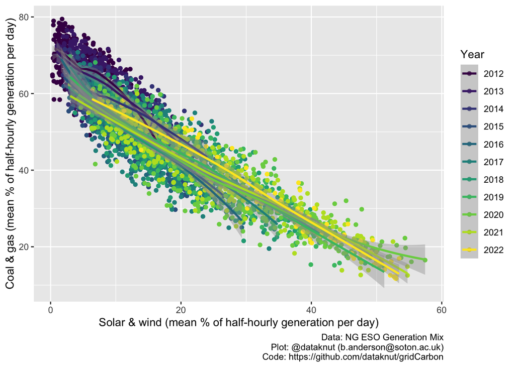

Figure 4.1: Mean half-hourly % generation by each type per day

```r
ggplot2::ggplot(plotDT[dv_year > 2011], aes(x = mean_dv_solar_wind_pc,
                            y = mean_dv_coal_gas_pc,
                            colour = as.factor(dv_year))) +
  geom_point() +
  geom_smooth() +
  scale_colour_viridis_d(name = "Year") +
  labs(x = "Solar & wind (mean % of half-hourly generation per day)",
       y = "Coal & gas (mean % of half-hourly generation per day)",
       caption = plotCap)
```

```r
# save it
ggplot2::ggsave(filename = "GB_plotMeanHalfHourPC.png",
                path = here::here("rmd","plots"),
                height = 5)
```

Download plot.

Figure 4.2 shows the percentage of daily generation by type. This is less convoluted as it is the sum of generation per day for the two categories (solar + wind vs gas + coal) as a % of total daily generation.

Again the smoothed curve is estimated for each year.

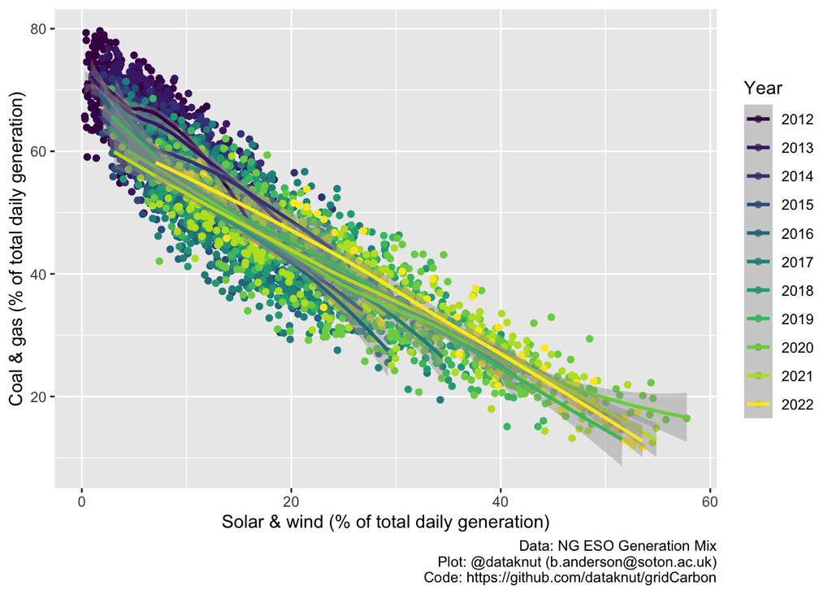

Figure 4.2: Percentage of daily generation by type

```r
ggplot2::ggplot(plotDT[dv_year > 2011], aes(x = 100 * total_dv_solar_wind_pc,
                            y = 100 * total_dv_coal_gas_pc,
                            colour = as.factor(dv_year))) +
  geom_point() +
  geom_smooth() +
  scale_colour_viridis_d(name = "Year") +
  labs(x = "Solar & wind (% of total daily generation)",
       y = "Coal & gas (% of total daily generation)",
       caption = plotCap)
```

```r
ggplot2::ggsave(filename = "GB_plotDailyPC.png",
                path = here::here("rmd","plots"),
                height = 5)
```

Download plot.

# 5 Half-hourly plots

Just cos we can… helpfully split into ‘peak’ and ‘off peak’ periods.

Again the smoothed curve is estimated for each year (and demand period).

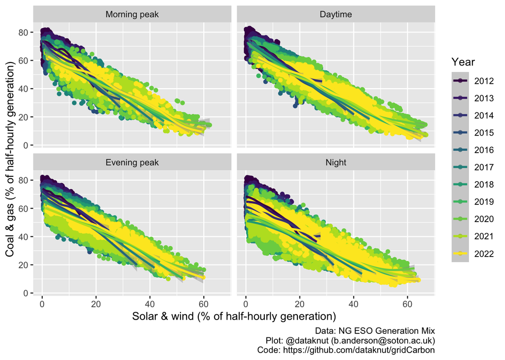

Figure 5.1: Percentage of half-hourly generation by type

```r
dt_orig[, dv_year := lubridate::year(dv_dateTime)]
dt_orig[, dv_hms := hms::as_hms(dv_dateTime)]
# half-hours are the start of the half hours (we think)
dt_orig[, dv_peak := "Night"] # default
dt_orig[, dv_peak := ifelse(dv_hms >= hms::as_hms("07:00:00") & dv_hms < hms::as_hms("09:00:00") , "Morning peak", dv_peak)]
dt_orig[, dv_peak := ifelse(dv_hms > hms::as_hms("09:00:00") & dv_hms < hms::as_hms("16:00:00") , "Daytime", dv_peak)]
dt_orig[, dv_peak := ifelse(dv_hms >= hms::as_hms("16:00:00") & dv_hms < hms::as_hms("21:00:00") , "Evening peak", dv_peak)]

# re-order for plots & tables

dt_orig[, dv_peak := factor(dv_peak, levels = c("Morning peak", "Daytime", "Evening peak", "Night"))]

#table(dt_orig$dv_peak)

# t <- dt_orig[, .(nObs = .N,
#                  startHour = min(lubridate::hour(dv_hms)),
#                  endHour = max(lubridate::hour(dv_hms))
#                  ), keyby = .(dv_peak)]
#
# makeFlexTable(t, cap = "Definition of peak")

dt_orig[, dv_hour := lubridate::hour(dv_dateTime)]
# check coding
# table(dt_orig$dv_hour, dt_orig$dv_peak, useNA = "always")

ggplot2::ggplot(dt_orig[dv_year > 2011], aes(x = dv_solar_wind_pc,
                            y = dv_coal_gas_pc,
                            colour = as.factor(dv_year))) +
  geom_point() +
  facet_wrap(. ~ dv_peak) +
  geom_smooth() +
  scale_colour_viridis_d(name = "Year") +
  labs(x = "Solar & wind (% of half-hourly generation)",
       y = "Coal & gas (% of half-hourly generation)",
       caption = plotCap)
```

```r
ggplot2::ggsave(filename = "GB_plotHalfHourlyPC.png",
                path = here::here("rmd","plots"),
                height = 5)
```

Download plot.

# 6 Summary

That’s it.

You might want to look at recent academic research on this topic:

- (Staffell 2017)
- (Staffell and Pfenninger 2018)

# 7 Annex

## 7.1 Data descriptors

### 7.1.1 NGESO gen mix data

```r
skimr::skim(dt_orig)
```

Table 7.1: Data summary

| Name | dt_orig |
| --- | --- |
| Number of rows | 232191 |
| Number of columns | 41 |
| Key | NULL |
| _______________________ |  |
| Column type frequency: |  |
| difftime | 1 |
| factor | 1 |
| numeric | 37 |
| POSIXct | 2 |
| ________________________ |  |
| Group variables | None |

**Variable type: difftime**

| skim_variable | n_missing | complete_rate | min | max | median | n_unique |
| --- | --- | --- | --- | --- | --- | --- |
| dv_hms | 0 | 1 | 0 secs | 84600 secs | 11:30:00 | 48 |

**Variable type: factor**

| skim_variable | n_missing | complete_rate | ordered | n_unique | top_counts |
| --- | --- | --- | --- | --- | --- |
| dv_peak | 0 | 1 | FALSE | 4 | Nig: 101591, Day: 62881, Eve: 48370, Mor: 19349 |

**Variable type: numeric**

| skim_variable | n_missing | complete_rate | mean | sd | p0 | p25 | p50 | p75 | p100 | hist |
| --- | --- | --- | --- | --- | --- | --- | --- | --- | --- | --- |
| GAS | 0 | 1 | 12651.82 | 5286.26 | 1556.0 | 8490.0 | 12752.0 | 16756.0 | 27472.0 | ▅▇▇▅▁ |
| COAL | 0 | 1 | 7066.87 | 6655.78 | 0.0 | 765.0 | 5366.0 | 12572.0 | 26044.0 | ▇▃▃▂▁ |
| NUCLEAR | 0 | 1 | 6839.14 | 1208.78 | 2488.0 | 5961.0 | 7022.0 | 7799.0 | 9342.0 | ▁▂▅▇▃ |
| WIND | 0 | 1 | 3808.66 | 3750.17 | 0.0 | 935.0 | 2556.0 | 5521.0 | 18546.0 | ▇▃▁▁▁ |
| HYDRO | 0 | 1 | 399.82 | 246.58 | 0.0 | 195.0 | 370.0 | 569.0 | 1403.0 | ▇▇▅▁▁ |
| IMPORTS | 0 | 1 | 2119.87 | 1174.72 | 0.0 | 1288.0 | 2224.0 | 2992.0 | 5908.0 | ▅▆▇▂▁ |
| BIOMASS | 0 | 1 | 663.40 | 1007.01 | 0.0 | 0.0 | 0.0 | 1534.0 | 3262.0 | ▇▁▁▂▁ |
| OTHER | 0 | 1 | 486.13 | 646.13 | 0.0 | 26.0 | 135.0 | 767.0 | 2462.0 | ▇▂▁▁▁ |
| SOLAR | 0 | 1 | 718.88 | 1540.91 | 0.0 | 0.0 | 0.0 | 536.5 | 9680.0 | ▇▁▁▁▁ |
| STORAGE | 0 | 1 | 296.10 | 357.16 | 0.0 | 0.0 | 246.0 | 438.0 | 2660.0 | ▇▂▁▁▁ |
| GENERATION | 0 | 1 | 35050.69 | 7389.76 | 18137.0 | 29310.0 | 34901.0 | 40244.0 | 59577.0 | ▃▇▇▃▁ |
| CARBON_INTENSITY | 0 | 1 | 363.92 | 146.38 | 47.0 | 237.0 | 364.0 | 495.0 | 695.0 | ▃▇▆▇▂ |
| LOW_CARBON | 0 | 1 | 12429.90 | 4517.42 | 4626.0 | 8994.0 | 11232.0 | 15011.0 | 31266.0 | ▇▇▃▁▁ |
| ZERO_CARBON | 0 | 1 | 11766.50 | 3992.36 | 4027.0 | 8789.5 | 10764.0 | 14129.0 | 28889.0 | ▅▇▃▁▁ |
| RENEWABLE | 0 | 1 | 4927.36 | 4269.61 | 0.0 | 1470.0 | 3672.0 | 7196.0 | 23636.0 | ▇▃▂▁▁ |
| FOSSIL | 0 | 1 | 19718.69 | 8925.08 | 1700.0 | 12884.0 | 18850.0 | 25855.0 | 49096.0 | ▃▇▆▂▁ |
| GAS_perc | 0 | 1 | 35.65 | 12.39 | 4.7 | 26.4 | 36.6 | 45.3 | 73.6 | ▂▆▇▅▁ |
| COAL_perc | 0 | 1 | 18.71 | 16.30 | 0.0 | 2.4 | 16.5 | 33.9 | 60.6 | ▇▃▃▃▁ |
| NUCLEAR_perc | 0 | 1 | 20.28 | 5.29 | 8.0 | 16.4 | 19.6 | 23.4 | 43.1 | ▂▇▃▁▁ |
| WIND_perc | 0 | 1 | 11.47 | 11.66 | 0.0 | 2.7 | 7.5 | 16.5 | 64.1 | ▇▂▁▁▁ |
| HYDRO_perc | 0 | 1 | 1.12 | 0.65 | 0.0 | 0.6 | 1.1 | 1.6 | 4.2 | ▇▇▃▁▁ |
| IMPORTS_perc | 0 | 1 | 6.48 | 3.90 | 0.0 | 3.6 | 6.5 | 9.2 | 22.6 | ▆▇▅▁▁ |
| BIOMASS_perc | 0 | 1 | 2.06 | 3.17 | 0.0 | 0.0 | 0.0 | 4.7 | 16.1 | ▇▂▂▁▁ |
| OTHER_perc | 0 | 1 | 1.45 | 1.99 | 0.0 | 0.1 | 0.4 | 2.2 | 10.5 | ▇▂▁▁▁ |
| SOLAR_perc | 0 | 1 | 2.02 | 4.43 | 0.0 | 0.0 | 0.0 | 1.4 | 34.0 | ▇▁▁▁▁ |
| STORAGE_perc | 0 | 1 | 0.75 | 0.87 | 0.0 | 0.0 | 0.6 | 1.1 | 7.9 | ▇▁▁▁▁ |
| GENERATION_perc | 0 | 1 | 100.00 | 0.00 | 100.0 | 100.0 | 100.0 | 100.0 | 100.0 | ▁▁▇▁▁ |
| LOW_CARBON_perc | 0 | 1 | 36.95 | 15.01 | 10.7 | 25.3 | 33.9 | 45.7 | 91.1 | ▆▇▃▂▁ |
| ZERO_CARBON_perc | 0 | 1 | 34.89 | 13.32 | 10.7 | 24.7 | 32.3 | 42.4 | 85.1 | ▅▇▃▁▁ |
| RENEWABLE_perc | 0 | 1 | 14.61 | 12.92 | 0.0 | 4.2 | 10.7 | 21.3 | 68.2 | ▇▃▂▁▁ |
| FOSSIL_perc | 0 | 1 | 54.36 | 17.19 | 5.4 | 42.5 | 55.6 | 68.4 | 88.0 | ▁▃▇▇▅ |
| dv_coal_gas_pc | 0 | 1 | 54.36 | 17.19 | 5.3 | 42.5 | 55.6 | 68.4 | 88.0 | ▁▃▇▇▅ |
| dv_solar_wind_pc | 0 | 1 | 13.49 | 12.76 | 0.0 | 3.2 | 9.5 | 19.9 | 66.9 | ▇▃▂▁▁ |
| dv_coal_gas | 0 | 1 | 19718.69 | 8925.08 | 1700.0 | 12884.0 | 18850.0 | 25855.0 | 49096.0 | ▃▇▆▂▁ |
| dv_solar_wind | 0 | 1 | 4527.54 | 4210.49 | 0.0 | 1118.0 | 3249.0 | 6710.0 | 22832.0 | ▇▃▂▁▁ |
| dv_year | 0 | 1 | 2015.13 | 3.82 | 2009.0 | 2012.0 | 2015.0 | 2018.0 | 2022.0 | ▇▇▆▇▆ |
| dv_hour | 0 | 1 | 11.50 | 6.92 | 0.0 | 5.0 | 11.0 | 17.0 | 23.0 | ▇▇▆▇▇ |

**Variable type: POSIXct**

| skim_variable | n_missing | complete_rate | min | max | median | n_unique |
| --- | --- | --- | --- | --- | --- | --- |
| DATETIME | 0 | 1 | 2009-01-01 | 2022-03-31 07:00:00 | 2015-08-16 15:30:00 | 232191 |
| dv_dateTime | 0 | 1 | 2009-01-01 | 2022-03-31 07:00:00 | 2015-08-16 15:30:00 | 232191 |

## 7.2 R environment

Packages etc:

- base R (R Core Team 2016)
- bookdown (Xie 2016a)
- data.table (Dowle et al. 2015)
- ggplot2 (Wickham 2009)
- here (Müller 2017)
- hms (Müller 2018)
- knitr (Xie 2016b)
- lubridate (Grolemund and Wickham 2011)
- rmarkdown (Allaire et al. 2018)

# References

Allaire, JJ, Yihui Xie, Jonathan McPherson, Javier Luraschi, Kevin Ushey, Aron Atkins, Hadley Wickham, Joe Cheng, and Winston Chang. 2018. *Rmarkdown: Dynamic Documents for r*. https://CRAN.R-project.org/package=rmarkdown.

Dowle, M, A Srinivasan, T Short, S Lianoglou with contributions from R Saporta, and E Antonyan. 2015. *Data.table: Extension of Data.frame*. https://CRAN.R-project.org/package=data.table.

Grolemund, Garrett, and Hadley Wickham. 2011. “Dates and Times Made Easy with lubridate.” *Journal of Statistical Software* 40 (3): 1–25. http://www.jstatsoft.org/v40/i03/.

Müller, Kirill. 2017. *Here: A Simpler Way to Find Your Files*. https://CRAN.R-project.org/package=here.

———. 2018. *Hms: Pretty Time of Day*. https://CRAN.R-project.org/package=hms.

R Core Team. 2016. *R: A Language and Environment for Statistical Computing*. Vienna, Austria: R Foundation for Statistical Computing. https://www.R-project.org/.

Staffell, Iain. 2017. “Measuring the Progress and Impacts of Decarbonising British Electricity.” *Energy Policy* 102 (March): 463–75. https://doi.org/10.1016/j.enpol.2016.12.037.

Staffell, Iain, and Stefan Pfenninger. 2018. “The Increasing Impact of Weather on Electricity Supply and Demand.” *Energy* 145 (February): 65–78. https://doi.org/10.1016/j.energy.2017.12.051.

Wickham, Hadley. 2009. *Ggplot2: Elegant Graphics for Data Analysis*. Springer-Verlag New York. http://ggplot2.org.

Xie, Yihui. 2016a. *Bookdown: Authoring Books and Technical Documents with R Markdown*. Boca Raton, Florida: Chapman; Hall/CRC. https://github.com/rstudio/bookdown.

———. 2016b. *Knitr: A General-Purpose Package for Dynamic Report Generation in r*. https://CRAN.R-project.org/package=knitr.